# Homework #4

Zechen Wang (zew20@pitt.edu)

February 25, 2019

```r
setwd("D:/workspace/r/INFSCI 2160 Data Mining/Week04")

library(dplyr)
library(ggplot2)
library(glmnet)
library(tree)
library(randomForest)
library(pROC)
library(rsample)
library(MASS)
library(car)
library(class)
library(rpart)
library(ROCR)
library(caret)
library(fastDummies)
library(ISLR)
library(e1071)
```

## Question #1

- Run k-fold cross validation with a random forest model on your training data. List your most important predictors in order from most important to least. How many predictors are optimal for this dataset?

```r
set.seed(123)

telco <- read.csv("WA_Fn-UseC_-Telco-Customer-Churn.csv", header = T, sep = ',', strip.white = T, stringsAsFactors = T)
telco <- telco %>% drop_na(TotalCharges)
telco_factors <- unlist(lapply(telco, is.factor))
telco[, telco_factors] <- lapply(telco[, telco_factors], as.numeric)
telco[, telco_factors] <- telco[, telco_factors] - 1
telco_origin <- telco
telco$Churn <- as.factor(telco$Churn)

telco_train_test_split <- initial_split(telco, prop = 0.8)
telco_train_tbl <- training(telco_train_test_split)
telco_test_tbl <- testing(telco_train_test_split)
telco_rf <- randomForest(formula = Churn ~ ., data = telco_train_tbl, importance = TRUE, ntree = 50)
telco_var_importance <- data.frame(importance(telco_rf))
telco_var_importance
```

```
##                           X0           X1 MeanDecreaseAccuracy
## customerID        0.04000072 -1.341474472           -0.6312738
## gender           -3.27610556  0.832574239           -1.9414981
## SeniorCitizen     2.76578759  1.282156442            3.0679387
## Partner           0.61264079  0.754232983            1.0284197
## Dependents       -0.44982224  0.979810236            0.3945764
## tenure            9.27847211  7.000992028           12.5145117
## PhoneService      0.25801473  1.284045203            1.0221614
## MultipleLines    -0.52408762  4.041803578            1.9658534
## InternetService   4.29303082  5.747855432            7.0296155
## OnlineSecurity    4.74640430  6.044859757            6.1025451
## OnlineBackup      5.11848058  2.561535319            6.0895462
## DeviceProtection  3.79861742 -2.574787536            3.3408142
## TechSupport       4.16387455  6.027626761            6.8341723
## StreamingTV       2.58702188  0.874046165            2.9544834
## StreamingMovies   0.76641713  1.979038251            2.0095748
## Contract          1.56601584 11.287522070           10.3885298
## PaperlessBilling -0.77800226  3.254718257            1.7269869
## PaymentMethod     1.10225632  0.005807605            0.7828948
## MonthlyCharges    5.73122972 10.324663295           10.8853735
## TotalCharges     10.33297177  3.682859389           14.6712144
##                  MeanDecreaseGini
## customerID             239.928899
## gender                  43.620336
## SeniorCitizen           35.816431
## Partner                 39.139360
## Dependents              31.910410
## tenure                 282.066265
## PhoneService             9.410107
## MultipleLines           41.297993
## InternetService         51.650581
## OnlineSecurity          91.964485
## OnlineBackup            51.920274
## DeviceProtection        39.583350
## TechSupport             83.430781
## StreamingTV             29.852328
## StreamingMovies         30.672229
## Contract               158.808877
## PaperlessBilling        42.915453
## PaymentMethod           86.819379
## MonthlyCharges         307.644168
## TotalCharges           307.627463
```

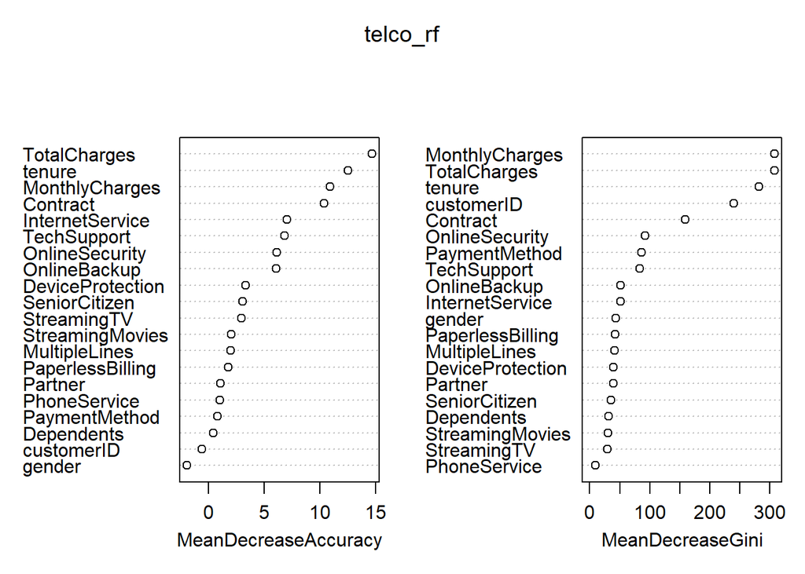

```r
varImpPlot(telco_rf)
```

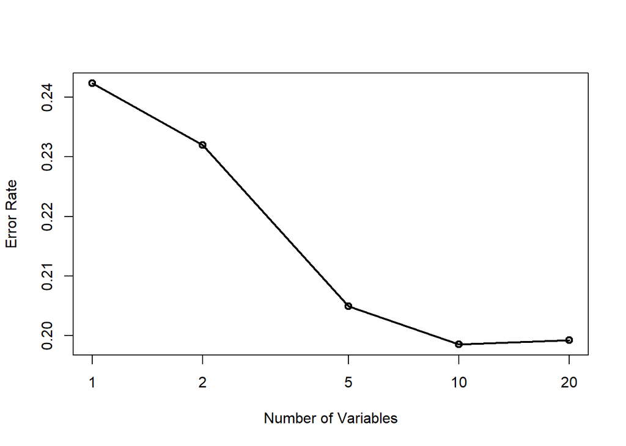

```r
telco_crossval <- rfcv(telco_train_tbl[, c(1:20)], telco_train_tbl$Churn, cv.fold = 5, step = 0.5)
with(telco_crossval, plot(n.var, error.cv, log="x", type="o", lwd=2,
                           xlab="Number of Variables", ylab="Error Rate"))
```

```r
telco_crossval$error.cv
```

```
##        20        10         5         2         1
## 0.1992535 0.1985425 0.2049413 0.2319588 0.2422680
```

- List your most important predictors in order from most important to least. How many predictors are optimal for this dataset?

**Answer:**

most important features are:

- TotalCharges
- tenure
- MonthlyCharges
- Contract
- InternetService
- TechSupport
- OnlineSecurity
- OnlineBackup
- DeviceProtection
- SeniorCitizen

There are 10 poredictors which are optimal for this dataset.

```r
top.predictors <- c("TotalCharges", "tenure", "MonthlyCharges", "Contract", "InternetService", "TechSupport", "OnlineSecurity", "OnlineBackup", "DeviceProtection", "SeniorCitizen")
top.predictors
```

```
##  [1] "TotalCharges"     "tenure"           "MonthlyCharges"
##  [4] "Contract"         "InternetService"  "TechSupport"
##  [7] "OnlineSecurity"   "OnlineBackup"     "DeviceProtection"
## [10] "SeniorCitizen"
```

## Question #2:

- Apply different classification techniques (3 minimum) (incl. logistic regression, kNN, Naive Bayesion, decision tree, SVM, random forest) on this dataset to predict customer churn. Answer the following questions for each model (remember to use variable selection techniques where necessary!):

### 1. Random Forest

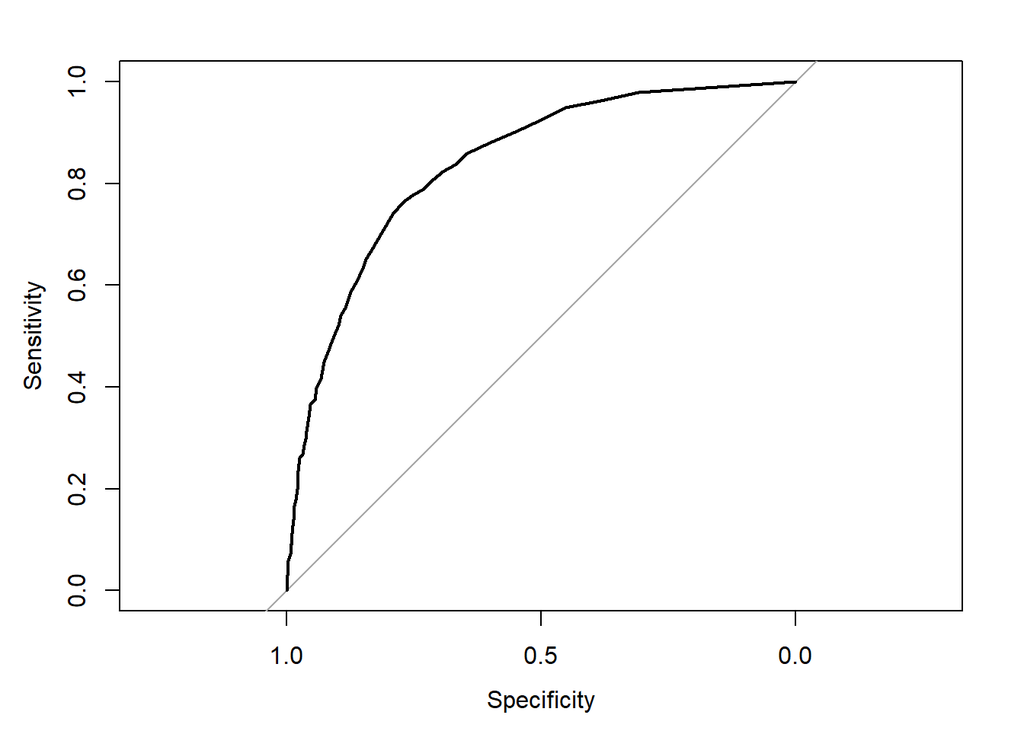

```r
telco_rf_10_vars <- randomForest(formula = Churn ~ TotalCharges + tenure + MonthlyCharges + Contract + InternetService + TechSupport + OnlineSecurity + OnlineBackup + DeviceProtection + SeniorCitizen, data = telco_train_tbl, importance = TRUE, ntree = 50)
telco_test_tbl <- telco_test_tbl %>%
    mutate(preds = predict(telco_rf_10_vars, telco_test_tbl),
           probs = predict(telco_rf_10_vars, telco_test_tbl, type = "prob")[, 1])
telco_rf_roc <- roc(telco_test_tbl$Churn, telco_test_tbl$probs)
telco_rf_roc_plot <- plot(telco_rf_roc)
```

```r
telco_rf_auc <- pROC::auc(telco_rf_roc)
```

**The AUC is 0.8377.**

```r
telco_rf_auc
```

```
## Area under the curve: 0.8377
```

- How confident are you in your model? How do you quantify your confidence?

**Answer:**

I use confidence interval to quantify my confidence. The confidence interval is “95% CI: 0.8152-0.8601”, the range is small so I am confident in my model.

```r
ci.auc(telco_rf_auc)
```

```
## 95% CI: 0.8152-0.8601 (DeLong)
```

- Create a confusion matrix of true vs. predicted customer churn for your best model. How did you choose your threshold for classification? What is your accuracy, precision, sensitivity, specificity, F1 score, and negative predictive value for this model?
- Evaluate your confusion matrix. Name one positive aspect of the results and one negative aspect of the results.

**Answer:**

I try to use Youden’s J-statistic to determine the threshold, but it results in less accuracy and F1 score, so I just use the default threshold 0.5.

- accuracy: 0.7916
- sensitivity: 0.9063
- specificity: 0.4949
- precision: 0.8227
- negative predictive value: 0.6713
- F1 score: 0.8625

Evaluate:

- positive: high sensitivity, predict TP well
- negative: low specificity, low performance on TN

```r
rf.cfMatrix <- confusionMatrix(telco_test_tbl$preds, telco_test_tbl$Churn)
rf.cfMatrix
```

```
## Confusion Matrix and Statistics
##
##           Reference
## Prediction   0   1
##          0 919 198
##          1  95 194
##
##                Accuracy : 0.7916
##                  95% CI : (0.7694, 0.8126)
##     No Information Rate : 0.7212
##     P-Value [Acc > NIR] : 8.264e-10
##
##                   Kappa : 0.4364
##  Mcnemar's Test P-Value : 2.539e-09
##
##             Sensitivity : 0.9063
##             Specificity : 0.4949
##          Pos Pred Value : 0.8227
##          Neg Pred Value : 0.6713
##              Prevalence : 0.7212
##          Detection Rate : 0.6536
##    Detection Prevalence : 0.7945
##       Balanced Accuracy : 0.7006
##
##        'Positive' Class : 0
##
```

### 2. Naive Bayes

```r
telco <- telco_origin
telco$Churn <- as.factor(telco$Churn)
telco_train_test_split <- initial_split(telco, prop = 0.8)
telco_train_tbl <- training(telco_train_test_split)
telco_test_tbl <- testing(telco_train_test_split)

model <- naiveBayes(Churn ~ ., data = telco_train_tbl)
model
```

```
##
## Naive Bayes Classifier for Discrete Predictors
##
## Call:
## naiveBayes.default(x = X, y = Y, laplace = laplace)
##
## A-priori probabilities:
## Y
##         0         1
## 0.7355137 0.2644863
##
## Conditional probabilities:
##    customerID
## Y       [,1]     [,2]
##   0 3553.553 2041.174
##   1 3503.973 2022.239
##
##    gender
## Y        [,1]      [,2]
##   0 0.5079749 0.4999968
##   1 0.5013441 0.5001663
##
##    SeniorCitizen
## Y        [,1]      [,2]
##   0 0.1307395 0.3371560
##   1 0.2614247 0.4395585
##
##    Partner
## Y        [,1]      [,2]
##   0 0.5304495 0.4991323
##   1 0.3649194 0.4815694
##
##    Dependents
## Y        [,1]      [,2]
##   0 0.3412276 0.4741789
##   1 0.1747312 0.3798647
##
##    tenure
## Y       [,1]     [,2]
##   0 37.72088 24.13831
```

[output cut: 56 more lines]

```
##
##    PaymentMethod
## Y       [,1]      [,2]
##   0 1.508700 1.1183514
##   1 1.758737 0.8864164
##
##    MonthlyCharges
## Y       [,1]     [,2]
##   0 61.09842 31.15952
##   1 74.70733 24.60260
##
##    TotalCharges
## Y       [,1]     [,2]
##   0 2552.574 2331.493
##   1 1548.480 1895.665
```

```r
test_probabilities <- data.frame(predict(model, telco_test_tbl, type = "raw"))
head(test_probabilities)
```

```
##           X0           X1
## 1 0.53104869 0.4689513057
## 2 0.98734503 0.0126549737
## 3 0.90337206 0.0966279387
## 4 0.04946897 0.9505310339
## 5 0.67412518 0.3258748242
## 6 0.99974055 0.0002594518
```

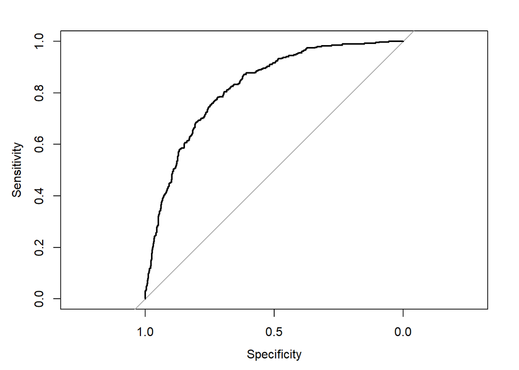

```r
telco_test_tbl <- telco_test_tbl %>%
    mutate(preds = predict(model, telco_test_tbl),
           no_probs = test_probabilities$X0,
           yes_probs = test_probabilities$X1)
telco_naive_roc <- roc(telco_test_tbl$Churn, telco_test_tbl$no_probs)
telco_naive_roc_plot <- plot(telco_naive_roc)
```

```r
telco_naive_auc <- pROC::auc(telco_naive_roc)
```

**AUC is 0.822.**

```r
telco_naive_auc
```

```
## Area under the curve: 0.822
```

- How confident are you in your model? How do you quantify your confidence?

**Answer:**

I use confidence interval to quantify my confidence. The confidence interval is “95% CI: 0.7988-0.8453”, the range is small so I am confident in my model.

```r
ci.auc(telco_naive_auc)
```

```
## 95% CI: 0.7988-0.8453 (DeLong)
```

- Create a confusion matrix of true vs. predicted customer churn for your best model. How did you choose your threshold for classification? What is your accuracy, precision, sensitivity, specificity, F1 score, and negative predictive value for this model?
- Evaluate your confusion matrix. Name one positive aspect of the results and one negative aspect of the results.

**Answer:**

I use the default threshold 0.5.

- accuracy: 0.7511
- sensitivity: 0.7571
- specificity: 0.7349
- precision: 0.8848
- negative predictive value: 0.5293
- F1 score: 0.8160

Evaluate:

- positive: high precision
- negative: low negative predictive value

```r
naiveBayes.cfMatrix <- confusionMatrix(telco_test_tbl$preds, telco_test_tbl$Churn)
naiveBayes.cfMatrix
```

```
## Confusion Matrix and Statistics
##
##           Reference
## Prediction   0   1
##          0 776 101
##          1 249 280
##
##                Accuracy : 0.7511
##                  95% CI : (0.7276, 0.7735)
##     No Information Rate : 0.729
##     P-Value [Acc > NIR] : 0.03278
##
##                   Kappa : 0.4385
##  Mcnemar's Test P-Value : 3.919e-15
##
##             Sensitivity : 0.7571
##             Specificity : 0.7349
##          Pos Pred Value : 0.8848
##          Neg Pred Value : 0.5293
##              Prevalence : 0.7290
##          Detection Rate : 0.5519
##    Detection Prevalence : 0.6238
##       Balanced Accuracy : 0.7460
##
##        'Positive' Class : 0
##
```

### 3. logistic regression

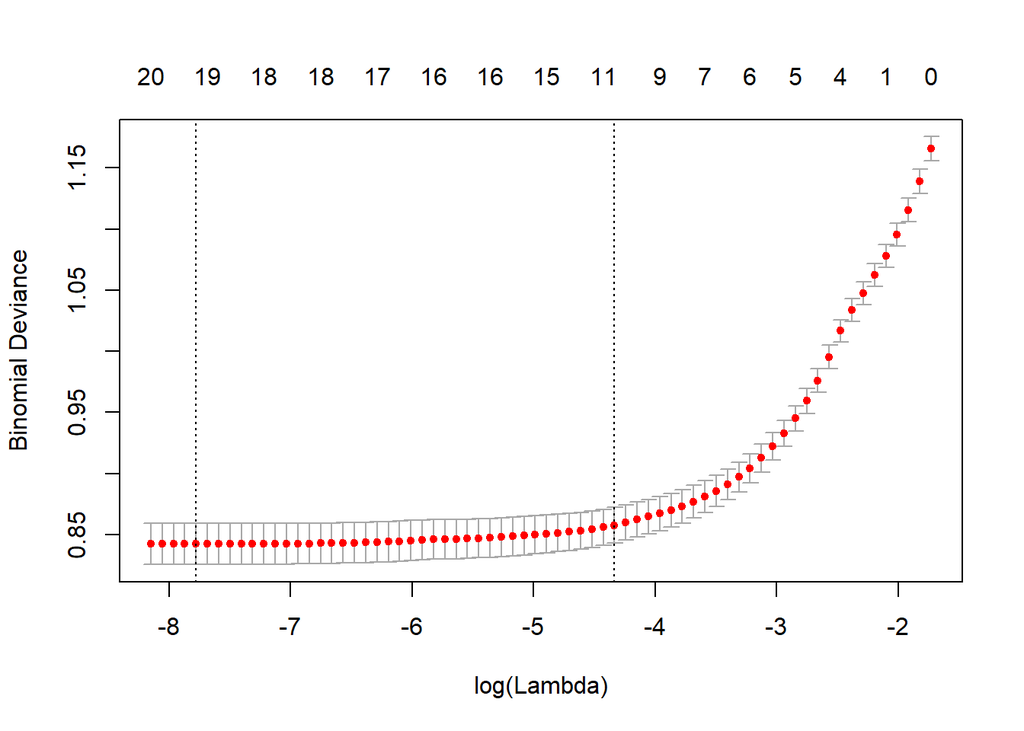

```r
telco <- telco_origin
normalize <- function(x) {
    x <- as.matrix(x)
    minAttr=apply(x, 2, min)
    maxAttr=apply(x, 2, max)
    x <- sweep(x, 2, minAttr, FUN="-")
    x=sweep(x, 2,  maxAttr-minAttr, "/")
    return (x)
}
telco[, c(-21)] <- normalize(telco[, c(-21)])
telco_train_test_split <- initial_split(telco, prop = 0.8)
telco_train_tbl <- training(telco_train_test_split)
telco_test_tbl <- testing(telco_train_test_split)
telco_vars_train <- telco_train_tbl[, c(-21)]
telco_vars_test <- telco_test_tbl[, c(-21)]
telco_target_train <- telco_train_tbl$Churn
telco_target_test <- telco_test_tbl$Churn
telco_logistic_lasso <- cv.glmnet(x = as.matrix(telco_vars_train), y = telco_target_train, alpha = 1, family="binomial")
plot(telco_logistic_lasso)
```

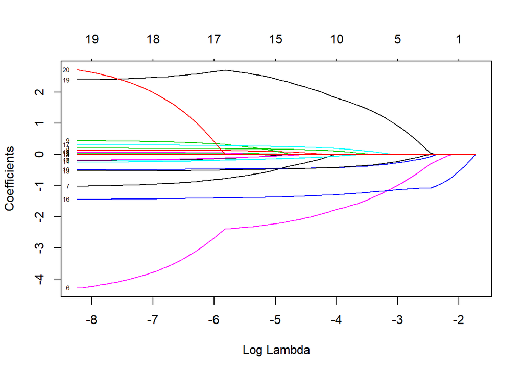

```r
plot(telco_logistic_lasso$glmnet.fit, "lambda", label = T)
```

```r
coef(telco_logistic_lasso, telco_logistic_lasso$lambda.min)
```

```
## 21 x 1 sparse Matrix of class "dgCMatrix"
##                              1
## (Intercept)      -0.0166083839
## customerID       -0.1906320083
## gender           -0.0007450331
## SeniorCitizen     0.1989733874
## Partner          -0.0066927572
## Dependents       -0.1873504070
## tenure           -4.1599414968
## PhoneService     -0.9996502453
## MultipleLines     0.1278437271
## InternetService   0.4344694192
## OnlineSecurity   -0.4879940530
## OnlineBackup     -0.2428873149
## DeviceProtection -0.1770741216
## TechSupport      -0.5347892588
## StreamingTV       .
## StreamingMovies   0.0380522510
## Contract         -1.4365729749
## PaperlessBilling  0.3067710826
## PaymentMethod     0.0686309068
## MonthlyCharges    2.4109934508
## TotalCharges      2.5382190461
```

```r
lasso.pred.test = predict(telco_logistic_lasso, s = telco_logistic_lasso$lambda.min, newx = as.matrix(telco_vars_test))
mse_telco <- mean((lasso.pred.test - telco_test_tbl$Churn)^2)
mse_telco
```

```
## [1] 7.104426
```

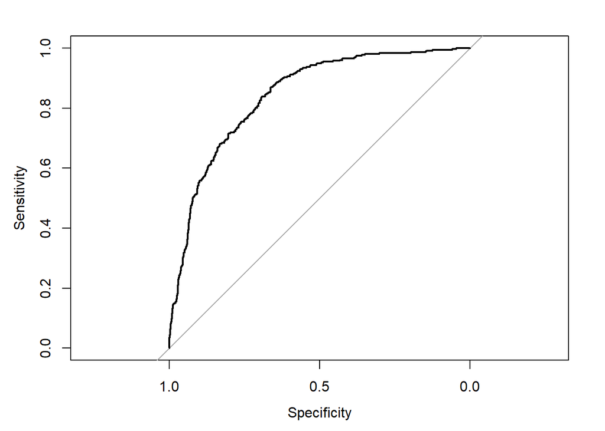

```r
telco_test_tbl <- telco_test_tbl %>%
    mutate(P_TEST = predict(telco_logistic_lasso, s = telco_logistic_lasso$lambda.min, newx = as.matrix(telco_vars_test), type = "response")[, 1])

telco_test_roc <- roc(telco_test_tbl$Churn, telco_test_tbl$P_TEST)
telco_test_roc_plot <- plot(telco_test_roc)
```

```r
telco_test_auc <- pROC::auc(telco_test_roc)
```

**AUC is 0.8422.**

```r
telco_test_auc
```

```
## Area under the curve: 0.8422
```

- How confident are you in your model? How do you quantify your confidence?

**Answer:**

I use confidence interval to quantify my confidence. The confidence interval is “95% CI: 0.8197-0.8647”, the range is small so I am confident in my model.

```r
ci.auc(telco_test_auc)
```

```
## 95% CI: 0.8197-0.8647 (DeLong)
```

- Create a confusion matrix of true vs. predicted customer churn for your best model. How did you choose your threshold for classification? What is your accuracy, precision, sensitivity, specificity, F1 score, and negative predictive value for this model?
- Evaluate your confusion matrix. Name one positive aspect of the results and one negative aspect of the results.

**Answer:**

I try to use Youden’s J-statistic to determine the threshold, but it results in less accuracy and F1 score, so I just use the default threshold 0.5.

- accuracy: 0.8065
- sensitivity: 0.8853
- specificity: 0.5698
- precision: 0.8608
- negative predictive value: 0.6231
- F1 score: 0.8729

Evaluate:

- positive: high sensitivity, predict TP well
- negative: low specificity, low performance on TN

```r
telco_test_tbl <- telco_test_tbl %>%
    mutate(P_RESP = ifelse(P_TEST >= 0.5, 1, 0))
telco_logistic_test_tbl <- telco_test_tbl
true <- telco_test_tbl$Churn
predicted <- telco_test_tbl$P_RESP
true <- as.factor(true)
predicted <- as.factor(predicted)
lasso.test.cfMatrix <- confusionMatrix(predicted, true)
lasso.test.cfMatrix
```

```
## Confusion Matrix and Statistics
##
##           Reference
## Prediction   0   1
##          0 934 151
##          1 121 200
##
##                Accuracy : 0.8065
##                  95% CI : (0.7849, 0.8269)
##     No Information Rate : 0.7504
##     P-Value [Acc > NIR] : 3.384e-07
##
##                   Kappa : 0.4685
##  Mcnemar's Test P-Value : 0.07868
##
##             Sensitivity : 0.8853
##             Specificity : 0.5698
##          Pos Pred Value : 0.8608
##          Neg Pred Value : 0.6231
##              Prevalence : 0.7504
##          Detection Rate : 0.6643
##    Detection Prevalence : 0.7717
##       Balanced Accuracy : 0.7276
##
##        'Positive' Class : 0
##
```

### 4. KNN

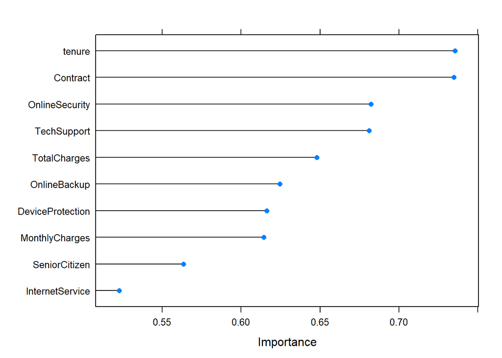

```r
telco <- telco_origin
telco_train_test_split <- initial_split(telco, prop = 0.8)
telco_train_tbl <- training(telco_train_test_split)
telco_test_tbl <- testing(telco_train_test_split)

telco_train_scaled <- data.frame(scale(telco_train_tbl[, c(top.predictors)]))
telco_test_scaled <- data.frame(scale(telco_test_tbl[, c(top.predictors)]))
df <- data.frame(scale(telco_train_tbl[, c(top.predictors, "Churn")]))
df$Churn <- as.factor(df$Churn)

ctrl <- trainControl(method="repeatedcv", repeats = 3)
knnFit <- train(Churn ~ ., data = df, method = "knn", trControl = ctrl, preProcess = c("center","scale"), tuneLength = 20)
importance <- varImp(knnFit, scale = F)
plot(importance)
```

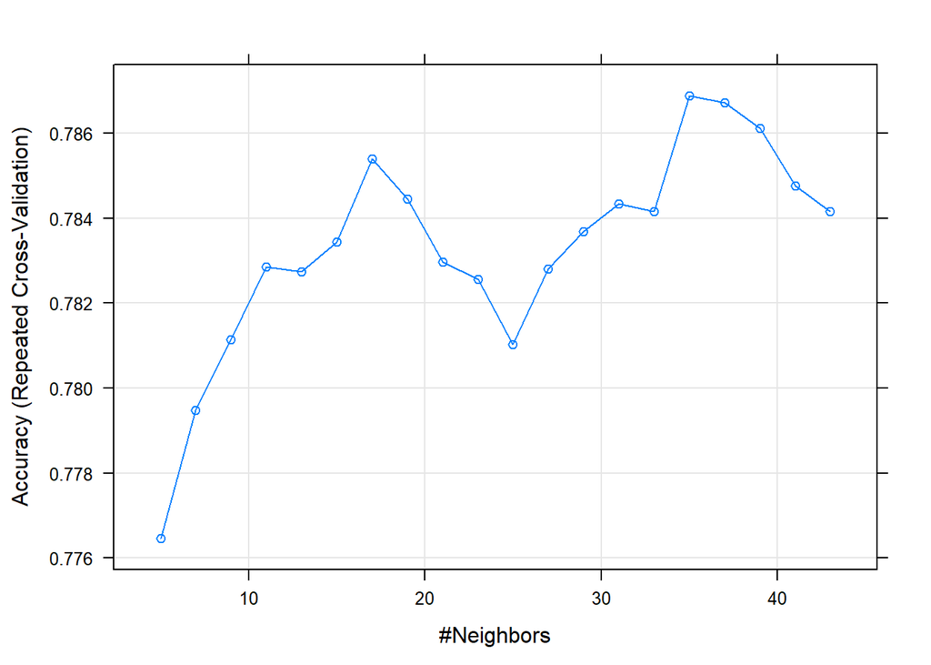

```r
plot(knnFit)
```

```r
knnFit
```

```
## k-Nearest Neighbors
##
## 5626 samples
##   10 predictor
##    2 classes: '-0.598512606865802', '1.67051160218204'
##
## Pre-processing: centered (10), scaled (10)
## Resampling: Cross-Validated (10 fold, repeated 3 times)
## Summary of sample sizes: 5064, 5064, 5063, 5063, 5062, 5063, ...
## Resampling results across tuning parameters:
##
##   k   Accuracy   Kappa
##    5  0.7764583  0.3889964
##    7  0.7794761  0.3912067
##    9  0.7811361  0.3935654
##   11  0.7828530  0.3958883
##   13  0.7827355  0.3927855
##   15  0.7834470  0.3935348
##   17  0.7854012  0.3974231
##   19  0.7844557  0.3935894
##   21  0.7829732  0.3921515
##   23  0.7825603  0.3936850
##   25  0.7810198  0.3881926
##   27  0.7827976  0.3928348
##   29  0.7836861  0.3947134
##   31  0.7843384  0.3981200
##   33  0.7841611  0.3988261
##   35  0.7868851  0.4071593
##   37  0.7867081  0.4084514
##   39  0.7861169  0.4069600
##   41  0.7847529  0.4035497
##   43  0.7841606  0.3991930
##
## Accuracy was used to select the optimal model using the largest value.
## The final value used for the model was k = 35.
```

```r
knnFit$bestTune[, 1]
```

```
## [1] 35
```

```r
nearest <- knn(train = telco_train_scaled, test = telco_test_scaled, cl = telco_train_tbl$Churn, k = knnFit$bestTune[, 1], prob = T)

telco_test_df <- data.frame(telco_test_tbl$Churn, nearest)
head(telco_test_df, n = 20L)
```

```
##    telco_test_tbl.Churn nearest
## 1                     0       0
## 2                     0       0
## 3                     1       1
## 4                     0       0
## 5                     0       0
## 6                     0       1
## 7                     0       0
## 8                     0       0
## 9                     0       0
## 10                    0       0
## 11                    1       1
## 12                    0       0
## 13                    0       0
## 14                    0       0
## 15                    0       1
## 16                    0       0
## 17                    0       0
## 18                    0       0
## 19                    1       1
## 20                    0       0
```

```r
telco_test_df <- telco_test_df %>%
    mutate(CORRECT_KNN = ifelse(telco_test_df$telco_test_tbl.Churn == telco_test_df$nearest, 1, 0))

KNN_CORRECT <- sum(telco_test_df$CORRECT_KNN) / nrow(telco_test_df)
KNN_CORRECT
```

```
## [1] 0.7859175
```

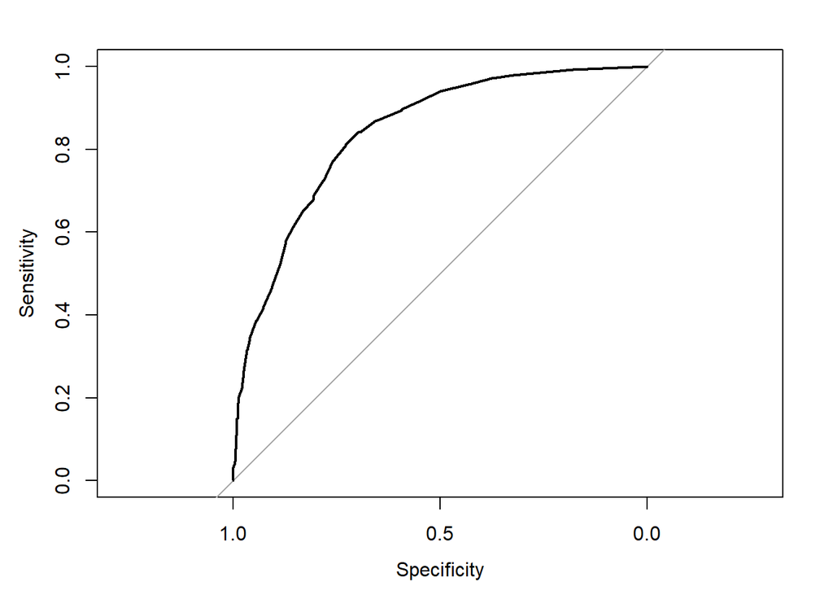

```r
prob <- attr(nearest, "prob")
prob <- ifelse(nearest == 0, 1-prob, prob)
df <- data.frame(telco_test_tbl$Churn, nearest, prob)
nearest_test_roc <- roc(telco_test_tbl$Churn, prob)
nearest_test_roc_plot <- plot(nearest_test_roc)
```

```r
nearest_test_auc <- pROC::auc(nearest_test_roc)
```

**AUC is 0.8402.**

```r
nearest_test_auc
```

```
## Area under the curve: 0.8402
```

- How confident are you in your model? How do you quantify your confidence?

**Answer:**

I use confidence interval to quantify my confidence. The confidence interval is “95% CI: 0.8182-0.8622”, the range is small so I am confident in my model.

```r
ci.auc(nearest_test_auc)
```

```
## 95% CI: 0.8182-0.8622 (DeLong)
```

- Create a confusion matrix of true vs. predicted customer churn for your best model. How did you choose your threshold for classification? What is your accuracy, precision, sensitivity, specificity, F1 score, and negative predictive value for this model?
- Evaluate your confusion matrix. Name one positive aspect of the results and one negative aspect of the results.

**Answer:**

I use the default threshold 0.5.

- accuracy: 0.7859
- sensitivity: 0.9050
- specificity: 0.4701
- precision: 0.8191
- negative predictive value: 0.6511
- F1 score: 0.8600

Evaluate:

- positive: high sensitivity, predict TP well
- negative: low specificity, low performance on TN

```r
true <- telco_test_df$telco_test_tbl.Churn
predicted <- telco_test_df$nearest
true <- as.factor(true)
predicted <- as.factor(predicted)
knn.test.cfMatrix <- confusionMatrix(predicted, true)
knn.test.cfMatrix
```

```
## Confusion Matrix and Statistics
##
##           Reference
## Prediction   0   1
##          0 924 204
##          1  97 181
##
##                Accuracy : 0.7859
##                  95% CI : (0.7635, 0.8071)
##     No Information Rate : 0.7262
##     P-Value [Acc > NIR] : 1.554e-07
##
##                   Kappa : 0.4107
##  Mcnemar's Test P-Value : 9.979e-10
##
##             Sensitivity : 0.9050
##             Specificity : 0.4701
##          Pos Pred Value : 0.8191
##          Neg Pred Value : 0.6511
##              Prevalence : 0.7262
##          Detection Rate : 0.6572
##    Detection Prevalence : 0.8023
##       Balanced Accuracy : 0.6876
##
##        'Positive' Class : 0
##
```

### Summary

- Which model performed best according to this metric (AUC)?

**Answer:**

The logistic regression model performed best according to AUC.

## Bonus question

- Create a lift table for your data. Display the table or a graph representing the table.

```r
telco_test_tbl <- telco_logistic_test_tbl
p_test_quantiles <- quantile(telco_test_tbl$P_TEST, probs = seq(0, 1, 0.20), na.rm = FALSE, names = TRUE, type = 9)
p_test_quantiles
```

```
##          0%         20%         40%         60%         80%        100%
## 0.001300133 0.028788269 0.120291100 0.278602329 0.540435844 0.832050474
```

```r
telco_test_tbl <- telco_test_tbl %>%
    mutate(prob_bins = ifelse(P_TEST <= 0.028788269, "Bin 1",
                              ifelse(P_TEST > 0.028788269 & P_TEST <= 0.120291100, "Bin 2",
                                     ifelse(P_TEST > 0.120291100 & P_TEST <= 0.278602329, "Bin 3",
                                            ifelse(P_TEST > 0.278602329 & P_TEST <= 0.540435844, "Bin 4",
                                                   ifelse(P_TEST > 0.540435844, "Bin 5", "Max Bin"))))))
prob_bins <- telco_test_tbl$prob_bins
table(true, predicted, prob_bins)
```

```
## , , prob_bins = Bin 1
##
##     predicted
## true   0   1
##    0 188  19
##    1  41  33
##
## , , prob_bins = Bin 2
##
##     predicted
## true   0   1
##    0 183  19
##    1  40  39
##
## , , prob_bins = Bin 3
##
##     predicted
## true   0   1
##    0 179  19
##    1  44  40
##
## , , prob_bins = Bin 4
##
##     predicted
## true   0   1
##    0 191  18
##    1  37  35
##
## , , prob_bins = Bin 5
##
##     predicted
## true   0   1
##    0 183  22
##    1  42  34
```

```r
lift_tbl <- telco_test_tbl[, c("P_TEST", "Churn")]
lift_tbl <- lift_tbl %>% arrange(desc(P_TEST))
head(lift_tbl)
```

```
##      P_TEST Churn
## 1 0.8320505     1
## 2 0.8193696     1
## 3 0.8158265     1
## 4 0.8144870     1
## 5 0.8111380     1
## 6 0.8097215     1
```

```r
baserate <- mean(telco_test_tbl$Churn)
baserate
```

```
## [1] 0.2496444
```

```r
n_test <- length(telco_test_tbl$Churn)
ax <- 1
ay_base <- baserate
ay_pred <- lift_tbl$Churn[1]

for (i in 2:n_test) {
    ax[i]=i
    ay_base[i]=baserate*i
    ay_pred[i]=ay_pred[i-1]+lift_tbl$Churn[i]
}
df=cbind(lift_tbl,ay_pred,ay_base)
df[1:20,]
```

```
##       P_TEST Churn ay_pred   ay_base
## 1  0.8320505     1       1 0.2496444
## 2  0.8193696     1       2 0.4992888
## 3  0.8158265     1       3 0.7489331
## 4  0.8144870     1       4 0.9985775
## 5  0.8111380     1       5 1.2482219
## 6  0.8097215     1       6 1.4978663
## 7  0.7949200     1       7 1.7475107
## 8  0.7916696     1       8 1.9971550
## 9  0.7910453     0       8 2.2467994
## 10 0.7904442     1       9 2.4964438
## 11 0.7903751     1      10 2.7460882
## 12 0.7848673     1      11 2.9957326
## 13 0.7828383     1      12 3.2453770
## 14 0.7817140     1      13 3.4950213
## 15 0.7777707     0      13 3.7446657
## 16 0.7774473     1      14 3.9943101
## 17 0.7772931     1      15 4.2439545
## 18 0.7758440     1      16 4.4935989
## 19 0.7728433     0      16 4.7432432
## 20 0.7705940     1      17 4.9928876
```

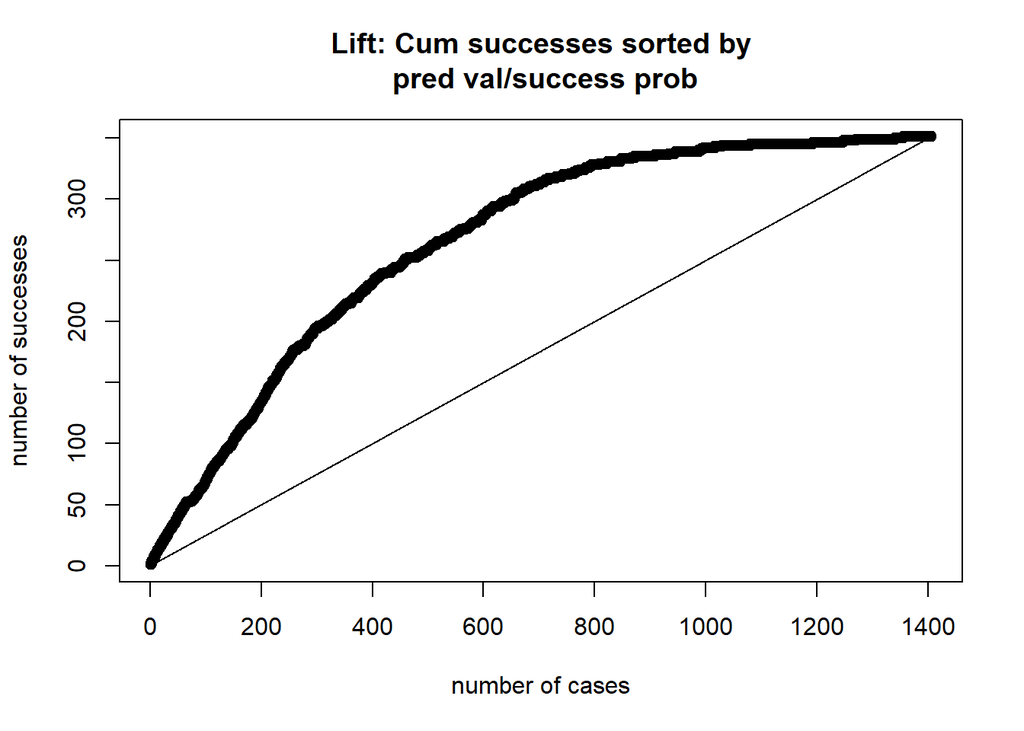

```r
plot(ax,ay_pred,xlab="number of cases",ylab="number of successes",
     main="Lift: Cum successes sorted by\n pred val/success prob")
points(ax,ay_base,type="l")
```

- Based on the totality of your analysis, how would you hypothetically suggest deploying this if you were working for this telco company?

**Answer:**

Since our sensitivity is always larger than specificity, which means our model has better performance on the “No Churn” customers, I would hypothetically suggest that focus more on the customers whose prediction result of churn is “No”.